# HW 6: Pronto!

Charles Lanfear

November 20, 2016

# Instructions

> Pronto! is Seattle’s first bike sharing program, which launched in fall 2014. You may have seen the green bike docks around campus. It was also [in the news frequently](http://www.king5.com/news/local/seattle/city-launches-investigation-into-sdot-director-over-pronto-ties/97249954) and [shut down](http://www.seattletimes.com/seattle-news/transportation/seattle-pronto-bike-share-shutting-down-friday/) after controversy.

> You will be using data from the [2015 Pronto Cycle Share Data Challenge](https://www.prontocycleshare.com/datachallenge). These are available for download as a 75 MB ZIP file from https://s3.amazonaws.com/pronto-data/open_data_year_one.zip. Once unzipped, the folder containing all the files is around 900 MB. The `open_data_year_one` folder contains a `README.txt` file that you should reference for documentation.

> Questions for you to answer are as quoted blocks of text. Put your code used to address these questions and any comments you have below each block. Remember the guiding principle: **don’t repeat yourself!**

# Getting the data in

> Set your working directory to be the `open_data_year_one` folder. Then use the `list.files()` command to return a character vector giving all the files in that folder, and store it to an object called `files_in_year_one`. Then use vector subsetting on `files_in_year_one` to remove the entries for `README.txt` (which isn’t data) and for `2015_status_data.csv` (which is massive and doesn’t have interesting information, so we’re going to exclude it). Thus, `files_in_year_one` should be a character vector with three entries.

```r
# load the libraries
library(readr)
library(dplyr)
library(ggplot2)
library(lubridate)
library(stringr)

# The folder containing my data is in the same folder as this .Rmd. The default
# working directory will thus contain the data folder.

# make my vector of filenames in the open_data_year_one folder
(files_in_year_one <- list.files("open_data_year_one"))
```

```
## [1] "2015_station_data.csv" "2015_status_data.csv"  "2015_trip_data.csv"
## [4] "2015_weather_data.csv" "README.txt"
```

```r
# remove the status data and README
(files_in_year_one <- files_in_year_one[-c(2, 5)])
```

```
## [1] "2015_station_data.csv" "2015_trip_data.csv"    "2015_weather_data.csv"
```

Note: if you put your .Rmd file inside “open_data_year_one”, then you need to be careful with which entries of `files_in_year_one` you keep or drop. You don’t want to include the entries that go with your .Rmd file or anything that comes up when you knit! Depending on what you named your .Rmd file and how it appears alphabetically relative to the files we do want, you would maybe need to refer to different entries.

> We want to read the remaining CSV files into data frames stored in a list called `data_list`. Preallocate this using `data_list <- vector("list", length(files_in_year_one))`.

```r
data_list <- vector("list", length(files_in_year_one))
```

> We would like the names of the list entries to be simpler than the file names. For example, we want to read the `2015_station_data.csv` file into `data_list[["station_data"]]`, and `2015_trip_data.csv` into `data_list[["trip_data"]]`. So, you should make a new vector called `data_list_names` giving the names of the objects to read in these CSV files to using `files_in_year_one`. Use the `substr` function to keep the portion of the `files_in_year_one` entries starting from the sixth character (which will drop the `2015_` part) and stopping at number of characters of each filename string, minus 4 (which will drop the `.csv` part).

```r
(data_list_names <- substr(files_in_year_one,
                           start = 6,
                           stop = nchar(files_in_year_one) - 4))
```

```
## [1] "station_data" "trip_data"    "weather_data"
```

> Set the names for `data_list` using the `names` function and the `data_list_names` vector.

```r
names(data_list) <- data_list_names
data_list
```

[output not shown]

> Then, write a `for` loop that uses `read_csv` from the `readr` package to read in all the CSV files contained in the ZIP file, `seq_along`ing the `files_in_year_one` vector. Store each of these files to its corresponding entry in `data_list`. The [data download demo](https://rebeccaferrell.github.io/CSSS508/Lectures/data_download_demo.html) might be a helpful reference.

> You will want to use the `cache=TRUE` chunk option for this chunk — otherwise you’ll have to wait for the data to get read in every single time you knit. You will also want to make sure you are using `readr::read_csv` and not base R’s `read.csv` as `readr`’s version is much faster, gives you a progress bar, and won’t convert all character variables to factors automatically.

```r
# read in the data in the open_data_year_one folder
# paste0 to get the filepaths right
for(i in seq_along(files_in_year_one)) {
    data_list[[i]] <- read_csv(paste0("open_data_year_one/", files_in_year_one[i]))
}
```

# Fixing data types

> Run `str` on `data_list` and look at how the variables came in using `read_csv`. Most should be okay, but some of the dates and times may be stored as character rather than dates or `POSIXct` date-time values. We also have lots of missing values for `gender` in the trip data because users who are not annual members do not report gender.

> First, patch up the missing values for `gender` in `data_list[["trip_data"]]`: if a user is a `Short-Term Pass Holder`, then put `"Unknown"` as their `gender`. Don’t make new objects, but rather modify the entries in `data_list` directly (e.g. `data_list[["trip_data"]] <- data_list[["trip_data"]] %>% mutate(...)`.

```r
str(data_list) # Output suppressed due to length
```

```r
# make gender Unknown when user is a short term ride
data_list[["trip_data"]] <- data_list[["trip_data"]] %>%
    mutate(gender = ifelse(usertype == "Short-Term Pass Holder",
                           "Unknown", gender))
```

> Now, use `dplyr::mutate_at`, functions from the `lubridate` package, and the `factor` function to fix any date/times, as well as to convert the `usertype` and `gender` variables to factor variables from the trip data. Don’t make new objects, but rather modify the entries in `data_list` directly.

```r
# make the date-times valid:

# station_data: make online a date
data_list[["station_data"]] <- data_list[["station_data"]] %>%
    mutate(online=mdy(online))

# trip_data: starttime, stoptime should be date-time
data_list[["trip_data"]] <- data_list[["trip_data"]] %>%
    mutate_at(vars(starttime, stoptime), funs(mdy_hm))

# weather_data: make Date a date
data_list[["weather_data"]] <- data_list[["weather_data"]] %>%
    mutate(Date=mdy(Date))
```

```r
# change variables with a few values to factors:

# trip_data: usertype, gender
data_list[["trip_data"]] <- data_list[["trip_data"]] %>%
    mutate_at(vars(usertype, gender), funs(factor))
```

# Identifying trip regions

> The `terminal`, `to_station_id`, and `from_station_id` columns in `data_list[["station_data"]]` and `data_list[["trip_data"]]` have a two or three character code followed by a hyphen and a numeric code. These character codes convey the broad geographic region of the stations (e.g. `CBD` is Central Business District, `PS` is Pioneer Square, `ID` is International District). Write a function called `region_extract` that can extract these region codes by taking a character vector as input and returning another character vector that just has these initial character codes. For example, if I run `region_extract(x = c("CBD-11", "ID-01"))`, it should give me as output a character vector with first entry `"CBD"` and second entry `"ID"`.

> Note: if you cannot get this working and need to move on with your life, try writing your function to just take the first two characters using `substr` and use that.

```r
# function to return the alpha part of a string before the hyphen
region_extract <- function(x) {
    beg_letters <- "^[A-Z]*" # matches uppercase letters from beginning, as many times as needed, until runs into some other kind of character
    return(str_extract(x, beg_letters))
}

# test it out:
region_extract(x = c("CBD-11", "ID-01"))
```

```
## [1] "CBD" "ID"
```

> Then on `data_list[["station_data"]]` and `data_list[["trip_data"]]`, make new columns called `terminal_region`, `to_station_region`, and `from_station_region` using your `region_extract` function.

```r
# station_data: get region from terminal
data_list[["station_data"]] <- data_list[["station_data"]] %>%
    mutate(terminal_region = region_extract(terminal))

# trip_data: get region from to_station_id and from_station_id
data_list[["trip_data"]] <- data_list[["trip_data"]] %>%
    mutate(to_station_region = region_extract(to_station_id),
           from_station_region = region_extract(from_station_id))
```

# Identifying rainy days

> The `Events` column in `data_list[["weather_data"]]` mentions if there was rain, thunderstorms, fog, etc. On some days you can see multiple weather events. Add a column to this data frame called `Rain` that takes the value `"Rain"` if there was rain, and `"No rain"` otherwise. You will need to use some string parsing since `"Rain"` is not always at the beginning of the string (but again, if you are running short on time, just look for `"Rain"` at the beginning using `substr` as a working but imperfect approach). Then convert the `Rain` variable to a factor.

```r
# if we see "Rain" in Events on weather_data, flag it
data_list[["weather_data"]] <- data_list[["weather_data"]] %>%
    mutate(Rain = ifelse(str_detect(Events, "Rain"),
                         "Rain",
                         "No rain")) %>%
    # a lot of days had no events recorded -- say "No rain" on these
    mutate(Rain = ifelse(is.na(Rain),
                         "No rain",
                         Rain)) %>%
    # make it a factor
    mutate(Rain = factor(Rain))
```

# Merging rainy weather and trips

> You have bike station region information now, and rainy weather information. Make a new data frame called `trips_weather` that joins `data_list[["trip_data"]]` with `data_list[["weather_data"]]` by trip start date so that the `Rain` column is added to the trip-level data (just the `Rain` column please, none of the rest of the weather info). You may need to do some date manipulation and extraction as seen in Week 5 slides to get a date variable from the `starttime` column that you can use in merging.

```r
trips_weather <- data_list[["trip_data"]] %>%
    # make a column for just the date, in "Date" format
    mutate(Date = as.Date(starttime)) %>%
    # merge onto weather data, with just the Date and Rain columns
    left_join(data_list[["weather_data"]] %>%
                  # use as.Date to make sure it ends up in "Date" format
                  mutate(Date = as.Date(Date)),
              by = "Date")
```

# Making a summarizing and plotting machine

> Now for the grand finale. Write a function `daily_rain_rides` that takes as input:
> - `region_code`: a region code (e.g. `"CBD"`, `"UW"`)
> - `direction`: indicates whether we are thinking of trips `"from"` or `"to"` a region

> and inside the function does the following:
> - Filters the data to trips that came **from** stations with that region code or went **to** stations with that region code (depending on the values of `direction` and `region_code`). For example, if I say `region_ code = "BT"` (for Belltown) and `direction = "from"`, then I want to keep rows for trips whose `from_station_region` is equal to `"BT"`.
> - Makes a data frame called `temp_df` with one row per day counting how many trips were in `region_code` going `direction`. This should have columns for trip starting date, how many trips there were that day, and whether there was rain or not that day. You’ll need to use `dplyr::group_by` and `summarize`.
> - Uses `temp_df` to make a `ggplot` scatterplot (`geom_point`) with trip starting date on the horizontal axis, number of trips on the vertical axis, and points colored `"black"` for days with no rain and `"deepskyblue"` for days with rain. Make sure the legend is clear and that the x axis is easy to understand without being overly labeled (control this with `scale_x_date`). The title of the plot should be customized to say which region code is shown and which direction is analyzed (e.g. “Daily rides going **to** **SLU**”) using `paste0`. Feel free to use whatever themeing you like on the plot or other tweaks to make it look great.
> - Returns the `ggplot` object with all its layers.

```r
daily_rain_rides <- function(region_code, direction) {
    # filter data conditionally on direction and region_code
    if(direction == "to") {
        temp_1 <- trips_weather %>%
            filter(to_station_region == region_code)
    }
    if(direction == "from") {
        temp_1 <- trips_weather %>%
            filter(from_station_region == region_code)
    }
    # summarize trips per day in that direction
    temp_df <- temp_1 %>%
        group_by(Date, Rain) %>%
        tally()
    # plot, colored by weather
    ggplot(data = temp_df,
           aes(x = Date,
               y = n,
               color = Rain,
               group = Rain)) +
        geom_point() +
        geom_smooth() +
        scale_x_date(name = "Date") +
        ylab("Number of rides") +
        scale_color_manual(name = "Weather",
                           values = c("black", "deepskyblue")) +
        ggtitle(paste0("Daily rides going ", direction,
                       " ", region_code)) +
        theme_minimal()
}
```

> Then, test out your function: make three plots using `daily_rain_rides`, trying out different values of the region code and direction to show it works.

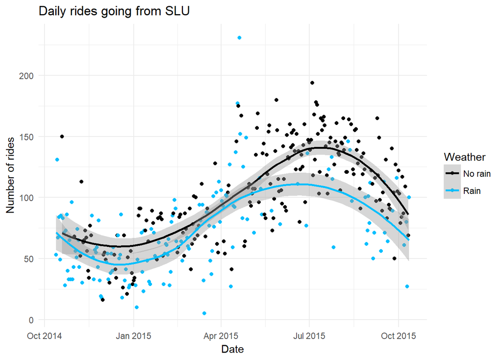

```r
daily_rain_rides("SLU", "from")
```

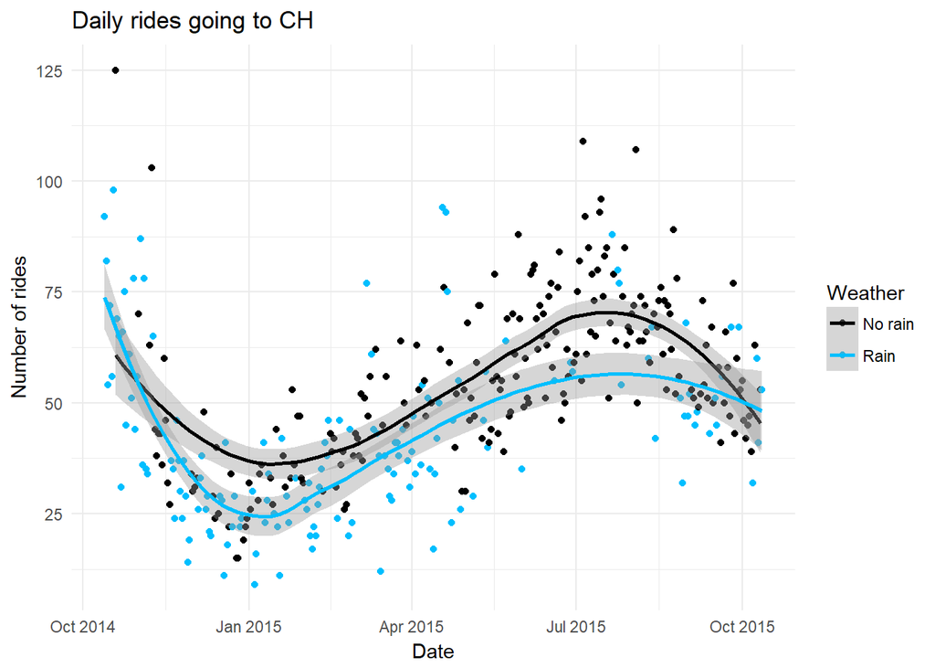

```r
daily_rain_rides("CH", "to")
```

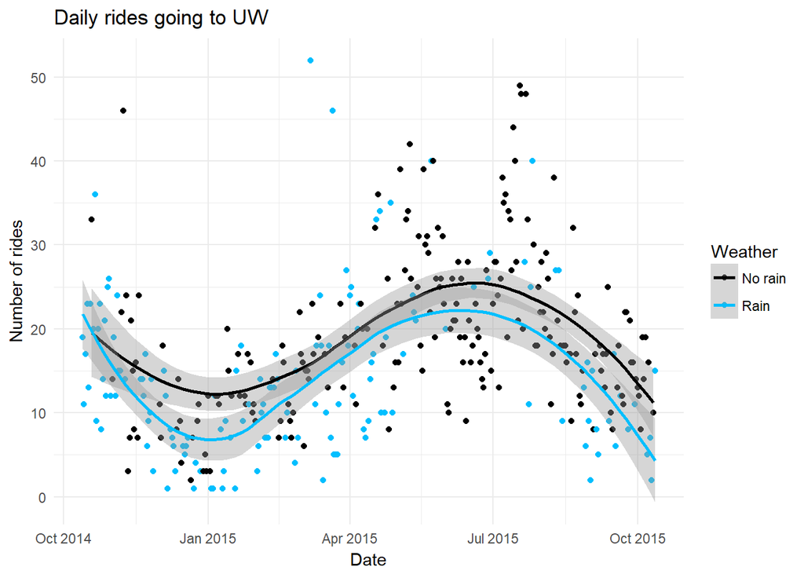

```r
daily_rain_rides("UW", "to")
```